# 통계밥법론2 Chap3 실습코드

## 4.8 Trilinear plost

**삼선형 그림(Trilinear plot)**은 3열 분할표 또는 상대 비율을 표시할 때, 세 변수에 대해 특수화된 방법이다.  
예를 들어, 개인은 세 개의 범주 중 하나에 배정되거나, 국회의원 선거에서 세 정당 간의 투표 분열을 볼 수 있다. 즉, 이 표시는 빈도와 비율에 모두 유용하다.

**Trilinear plot**은 관측치를 각 열의 상대 비율에 해당하는 좌표를 정삼각형 안에 있는 점으로 표시한다.  
세 개의 꼭짓점은 세 개의 열 중 하나에 100%가 발생할 때 세 개의 극단을 나타낸다.  
정확한 중심에 있는 한 점은 모든 3개의 열에서 1/3의 동일한 비율을 나타낸다. 실제로 각 점은 삼각형의 무게 중심을 나타내며 좌표는 해당 정점에 배치된 가중치를 나타낸다.

```r
library(ggtern)
```

`ggtern`패키지는 `ggplot2`의 기능을 확장하여 `ggplot2`에서는 사용할 수 없는 몇 가지의 새로운 플랏 형태를 제공하며, 특히, **삼항식 다이어그램**을 시각화할 수 있는 기능을 제공한다.

또한, **Trilinear plot**은 R에서 `ggtern`패키지에 포함된 `ggtern`함수를 통해 그릴 수 있다.  
- `ggtern(data, aes(x,y,z,colour))`

- data: Trilinear plot을 시각화함에 있어 사용되는 데이터
- x: x축에 사용되는 변수
- y: y축에 사용되는 변수
- z: z축에 사용되는 변수
- colour: 그룹을 구분하는데 사용되는 변수

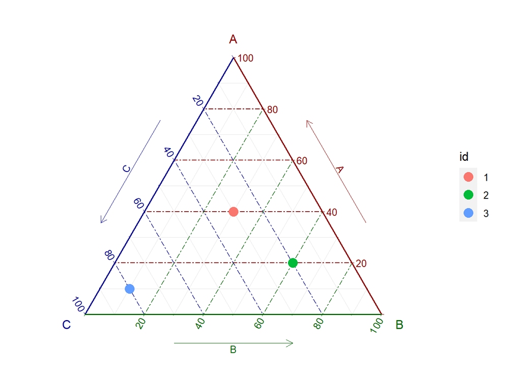

```r
DATA <- data.frame(
  A = c(40,20,10),
  B = c(30,60,10),
  C = c(30,20,80),
  id = c("1","2","3"))
aesthetic_mapping <- aes(x = C, y = A, z= B, colour = id)
ggtern(data = DATA, mapping = aesthetic_mapping) +
  geom_point(size = 4)+
  theme_rgbw()
```

위의 그림은 단순성을 위해 필요한 몇몇의 모수를 추가하지 않았다.  
각 꼭짓점 레이블이 지정된 변수의 100%에 해당하며 이 변수의 백분율은 중간점까지 선형적으로 감소한다.  
그리드 선은 각 축을 따라 백분율을 나타낸다.

*Example 4.20: Lifeboats on the Titanic*

```r
data("Lifeboats", package = "vcd")
head(Lifeboats)
```

```
##                launch side boat crew men women total cap
## 1 1912-04-15 00:45:00 Port    7    3   4    20    27  65
## 2 1912-04-15 00:55:00 Port    5    5   6    30    41  65
## 3 1912-04-15 01:00:00 Port    3   15  10    25    50  65
## 4 1912-04-15 01:10:00 Port    1    7   3     2    12  40
## 5 1912-04-15 01:20:00 Port    9    8   6    42    56  65
## 6 1912-04-15 01:25:00 Port   11    9   1    60    70  65
```

`Lifeboats`데이터는 타이나틱호 침몰 전에 진수된 구명보트 20척 중 18척에 대한 데이터로, `vcd`패키지 안에 포함돼 있다.

- launch: 탈출 시간 (POSIXt)
- side: 봍트의 사이드 (Factor variable - Port, Startboard)
- boat 보트의 고유 번호 (Factor variable - 1 ~ 16, A ~ D)
- crew: 탈출한 남자 승무원의 수 (Discrete variable)
- men: 탈출한 남자 승객의 수 (Discrete variable)
- women: 탈출한 여성 승객 + 탈출한 여자 승무원의 수 ((Discrete variable))
- total: 총 탈출한 승객의 수 (Discrete variable)
- cap: 보트의 수용인원 (Discrete variable)

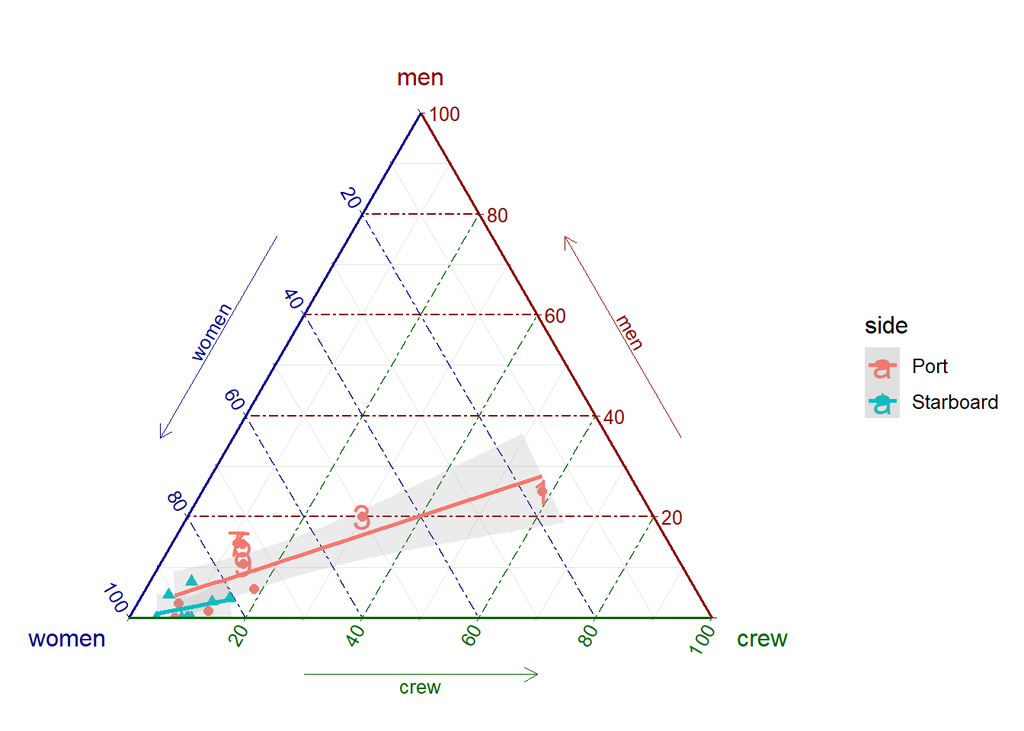

```r
Lifeboats$id <- ifelse(Lifeboats$men / Lifeboats$total > .1, as.character(Lifeboats$boat), "")
AES <- aes(x = women, y = men, z = crew,
           colour = side, shape = side, label = id)
ggtern(data = Lifeboats, mapping = AES) +
  geom_text(size=6)+
  geom_point(size = 2)+
  geom_smooth_tern(method = "lm", alpha = 0.2) +
  theme_rgbw()
```

`Lifeboats`의 `id`변수의 경우 탈출한 남성 승객의 수 / 총 승객의 탈출 인원 수가 0.1보다 큰 경우 `Lifeboats`데이터의 `boat id`를 가지도록 하였고 그 외에는 공백으로 남겨두도록 코딩을 진행하였다.

위의 그림을 보면 point가 좌측 하단 부근에 몰려있는 것을 확인할 수 있으며, 이는 보트를 통해 탈출을함에 있어 여성의 비율이 높은 것을 알 수 있다.  
또한, 우현에서 진수된 보트들은 대부분 여성 생존자가 많은 것에 비해, 좌현에서 진수된 보트들은 남성, 남성 승무원, 여성의 비율이 우현에서 진수된 보트보다는 더 높은 것을 확인할 수 있다.

우리는 2개의 side에서 발사된 보트의 구성의 차이를 살펴보기 위해 선형 회귀선을 추가하였다.  
보트1은 여성의 20%에 불과한 반면, 보트3은 50%, 보트 7,5,9는 약 75%의 비율을 가지고 있는 것을 확인할 수 있다.

## Summary of Chapter4

- 이원 교차표의 경우, 일차 빈도표에 비해 적용될 수 있는 분석기법이 많고 전처리 방법 또한 다양하므로 다양한 분석 기법을 익히는 것이 중요하다.
- **오즈비(Odds ratio)**의 경우 사건이 발생할 확률이 발생하지 않을 확률에 비해 몇 배 더 높은가의 의미를 가지고 있으며, 2차원의 분할표에서 많이 사용되는 개념 중 하나이다.
- 특정 변수에 대하여 평가자를 통해 변수를 측정하는 경우, 평가자의 평가가 어느 한 곳으로 치우치치않게 하는 것은 중요하다. 이러한 경우, **Kappa** 또는 **agreement plot**을 통해 평가자의 평가가 적합하게 이뤄젔는지에 대한 검정을 진행할 수 있다.
- **sieve diagram**은 분할표의 관찰빈도와 독립성을 가정했을 때의 기대빈도를 시각화를 통해 비교하고자 할때, 유용하게 사용할 수 있다.
- **association plot**은 **sieve diagram**과 달리, 직사각형의 면적이 편차를 나타내며 관찰빈도를 비교하기 보다는 편차에 대한 비교를 진행할 때 사용하는 방법이다.
- **CMHtest**는 분할표 변수 중, 순서형 수준이 포함되는 경우에 독립성 검정을 순서형 수준을 고려하여 진행할 수 있도록 도와주는 방법이다.
- 이차원 분할표를 넘어 삼차원, 사차원을 가는 경우 분할표의 변수 뿐만아니라, 분할표를 구분하는 **계층 변수**에 대한 관심을 가져야 하며, 이러한 계층 변수를 어떻게 처리할지에 대한 고민도 하는 것이 중요하다.
- **Fourfold display**는 여러개 혹은 단일 계층을 가지는 2x2 분할표에 대해 **오즈비**를 비교하고자 할 때, 유용하게 사용할 수 있는 방법이다.
- **Trilinear plot**은 3열 분할표에 대한 상대비율을 시각화를 통해 나타내고자 할 때, 유용하게 사용할 수 있는 방법이다.